# ChipSeq coverage maps for DLG2

This document details working with aligned ChIPseq data to look at coverage patterns for DLG2.

## Setting up the environment

These are packages you will need for this notebook. For exact versions used, please refer to the session info at the bottom of this notebook.

```r
##########################################################################################
library('tidyverse')
library('ggplot2')
library('RColorBrewer')
library('wiggleplotr')
library('GenomicRanges')
library('GenomicFeatures')
library('biomaRt')
library('org.Hs.eg.db')
library('TxDb.Hsapiens.UCSC.hg38.knownGene')
library('gggenes')
```

I want to set a base directory that we can use as a link to the directory where we will do most of the work. I use two directories here because the Workspace is what is pushed to GitHub and contains scripts and plot files, but the Repository is where more of the big data is stored that does not get pushed.

```r
##########################################################################################
generalDatasets = 'C:/Users/chughes/Documents/bccrc/projectsRepository/generalDatasets'
baseWorkspace = 'C:/Users/chughes/Documents/bccrc/projectsWorkspace/sorensenLab/relatedToDlg2'
baseRepository = 'C:/Users/chughes/Documents/bccrc/projectsRepository/sorensenLab/relatedToDlg2'
#generalDatasets = 'C:/Users/chris/OneDrive/Documents/bccrc/projectsRepository/generalDatasets'
#baseWorkspace = 'C:/Users/chris/OneDrive/Documents/bccrc/projectsWorkspace/sorensenLab/relatedToYbx1'
#baseRepository = 'C:/Users/chris/OneDrive/Documents/bccrc/projectsRepository/sorensenLab/relatedToYbx1'
```

## Data processing

First get the gtf file we used for alignment and will use for annotation below.

```r
##########################################################################################
totalGtf = as.data.frame(rtracklayer::import.gff('C:/Users/chughes/Documents/bccrc/databases/hg38/gencode_gtf/hg38.gtf.gz'))
```

The wiggleplot R package has some nice tools for plotting coverage data from bigwig files, which is what we have from deeptools. See an example below for the transcripts for DLG2 that have an annotated CCDS entry.

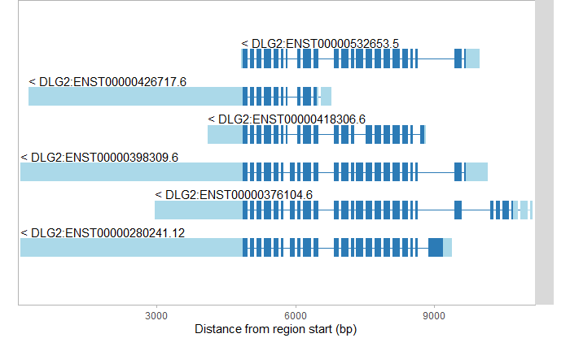

```r
##########################################################################################
plotTranscriptsFromUCSC(orgdb = org.Hs.eg.db, txdb = TxDb.Hsapiens.UCSC.hg38.knownGene,
                        gene_names = 'DLG2', transcript_ids = c('ENST00000398309.6','ENST00000280241.12','ENST00000426717.6','ENST00000376104.6',
                                                                'ENST00000418306.6','ENST00000532653.5'),
                        rescale_introns = TRUE)
```

I think this might be more flexible in the future if we extract this directly from the GTF.

```r
##########################################################################################
dlg2Gtf = totalGtf %>%
  filter(grepl('ENST00000398309.6', transcript_id))
##
dlg2Meta = dlg2Gtf %>%
  filter(grepl('transcript', type)) %>%
  dplyr::select(transcript_id, gene_id, gene_name, strand)
##
dlg2Exons = makeGRangesListFromDataFrame(dlg2Gtf %>%
  filter(grepl('exon', type)), split.field = 'transcript_id')
##
dlg2Cds = makeGRangesListFromDataFrame(dlg2Gtf %>%
  filter(grepl('CDS', type)), split.field = 'transcript_id')
```

Lets try plotting with these data.

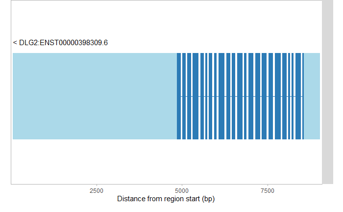

```r
##########################################################################################
plotTranscripts(dlg2Exons, dlg2Cds, dlg2Meta, rescale_introns = TRUE, )
ggsave(paste(baseRepository, '/sequencing20210114_a673ChipSeqReprocessingAynaud/rectangly_dlg2GeneLayout.pdf', sep = ''),
         height = 4, width = 4, useDingbats = FALSE)
```

The plot is messy, but it works. Now add some coverage data from our bigwig files that we generated previously. You need to keep the names as underscores here because that is what the tool is expecting.

```r
##########################################################################################
sampleData = tibble(sample_id = c('day7','day17'),
                    condition = factor(c('ewsLow','ewsHigh'), levels = c('ewsLow','ewsHigh')),
                    scaling_factor = 1)
##
bigwigFiles = c(paste(baseRepository, '/sequencing20210114_a673ChipSeqReprocessingAynaud/SRR8832669.chr11.bw', sep = ''),
                paste(baseRepository, '/sequencing20210114_a673ChipSeqReprocessingAynaud/SRR8832674.chr11.bw', sep = ''))
##
sampleData = sampleData %>%
  dplyr::mutate(bigWig = bigwigFiles)
as.data.frame(sampleData)
```

| sample_id | condition | scaling_factor | bigWig |
| --- | --- | --- | --- |
| day7 | ewsLow | 1 | C:/Users/chughes/Documents/bccrc/projectsRepository/sorensenLab/relatedToDlg2/sequencing20210114_a673ChipSeqReprocessingAynaud/SRR8832669.chr11.bw |
| day17 | ewsHigh | 1 | C:/Users/chughes/Documents/bccrc/projectsRepository/sorensenLab/relatedToDlg2/sequencing20210114_a673ChipSeqReprocessingAynaud/SRR8832674.chr11.bw |

```r
##
trackData = dplyr::mutate(sampleData, track_id = condition, colour_group = condition)
```

Now we are ready to make the plot.

```r
##########################################################################################
selectedTranscripts = c('ENST00000398309.6')
plotCoverage(dlg2Exons[selectedTranscripts], dlg2Cds[selectedTranscripts],
             dlg2Meta, trackData,
             heights = c(2,1), fill_palette = getGenotypePalette(),
             rescale_introns = FALSE, region_coords = c(83716153, 83827719))
```

```
Error in `[.data.frame`(dlg2Exons, selectedTranscripts) :
  undefined columns selected
```

I think I will just plot this manually because it is a bit tricky with the way the DLG2 gene is.

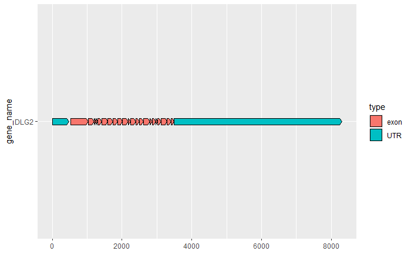

```r
##########################################################################################
##get the exons for the primary isoform in Ensembl
dlg2Exons = totalGtf %>%
  filter(grepl('DLG2', gene_name)) %>%
  filter(grepl('exon', type) | grepl('UTR', type)) %>%
  filter(grepl('ENST00000398309.6', transcript_id)) %>%
  arrange(-start)
##
##get the widths of the different exons
dlg2Widths = dlg2Exons[c(1:23,25),] %>%
  arrange(-start) %>%
  dplyr::select(width)
##
##collapse introns to a set length of 50
newStarts = 1
for(i in 2:nrow(dlg2Widths)){
  baseStart = 84923119
  totalWidth = (sum(dlg2Widths$width[1:(i-1)]) + 50)
  newStarts[i] = totalWidth
}
dlg2ExonsMod = dlg2Exons[c(1:23,25),] %>%
  arrange(-start) %>%
  mutate(newStarts = newStarts) %>%
  mutate(newEnds = newStarts + (width - 1))
##
##make a plot of the gene layout
ggplot(dlg2ExonsMod, aes(xmin = newStarts, xmax = newEnds, y = gene_name, fill = type)) +
  geom_gene_arrow(arrowhead_height = unit(3, "mm"), arrowhead_width = unit(1, "mm"))
```

I don’t really like the way this looks. I am wasting a bit too much time on this, it is kind of annoying. Just use the plotTranscripts from above. Move on to plotting the peak regions.

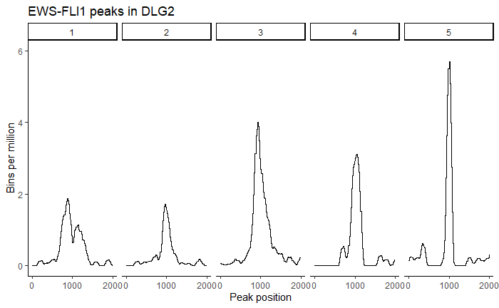

```r
##########################################################################################
#the transcript with the closest 'exon' is ENST00000426717.6
dlg2Gtf = totalGtf %>%
  filter(grepl('DLG2', gene_name)) %>%
  filter(grepl('gene', type)) %>%
  mutate(end = end + 100000) #we add 100kb here to search beyond the annotated TSS
##
macsPeaks = read_tsv(paste(baseRepository, '/sequencing20210114_a673ChipSeqReprocessingAynaud/SRR8832674_peaks.xls', sep = ''),
                     skip = 30,
                     col_names = c('chr','start','end','length','abs_summit','pileup','logPValue','fold_enrichment','logQValue','name')) %>%
  filter(grepl('chr11', chr)) %>%
  filter(start > dlg2Gtf$start & end < dlg2Gtf$end) %>%
  mutate(midPoint = start + round(length / 2, 0)) %>%
  filter(fold_enrichment >= 10)
##
#get the bigwig data
macsBw = rtracklayer::import(paste(baseRepository, '/sequencing20210114_a673ChipSeqReprocessingAynaud/SRR8832674.chr11.bw', sep = ''))
#make a new grange to subtract from these data
peakGrange = makeGRangesFromDataFrame(data.frame('seqname' = macsPeaks$chr,
                        'start' = macsPeaks$midPoint - 1000,
                        'end' = macsPeaks$midPoint + 1000,
                        'strand' = '*'))
#find the overlaps with the bigwig data
peakWindows = unlist(slidingWindows(peakGrange,1), use.names = TRUE)
peakWindows$peak = rep(seq(5,1,-1), each = 2001)
macsOverlaps = findOverlaps(peakWindows, macsBw, ignore.strand = TRUE)
macsCounts = as.data.frame(macsBw)[subjectHits(macsOverlaps),]
macsCounts$peakId = peakWindows$peak
macsCounts$indexLocation = rep(seq(1,2001,1), 5)

#make a test plot
ggplot(macsCounts, aes(indexLocation, score)) +
  geom_path() +
  scale_y_continuous(limits = c(0,6), breaks = seq(0,8,2)) +
  scale_x_continuous(limits = c(0,2005), breaks = seq(0,2000,1000)) +
  labs(x = 'Peak position', y = 'Bins per million', title = 'EWS-FLI1 peaks in DLG2') +
  theme_classic() +
  facet_wrap(~peakId, nrow = 1)

##looks good, so make a plot for each
accessions = c('SRR8832669','SRR8832670','SRR8832671','SRR8832672','SRR8832673','SRR8832674')
for(i in 1:length(accessions)){
  macsBw = rtracklayer::import(paste(baseRepository, '/sequencing20210114_a673ChipSeqReprocessingAynaud/',accessions[i],'.chr11.bw', sep = ''))
  macsOverlaps = findOverlaps(peakWindows, macsBw, ignore.strand = TRUE)
  macsCounts = as.data.frame(macsBw)[subjectHits(macsOverlaps),]
  macsCounts$peakId = peakWindows$peak
  macsCounts$indexLocation = rep(seq(1,2001,1), 5)
  ##
  ggplot(macsCounts, aes(indexLocation, score)) +
    geom_path() +
    scale_y_continuous(limits = c(0,6), breaks = seq(0,8,2)) +
    scale_x_continuous(limits = c(0,2005), breaks = seq(0,2000,1000)) +
    labs(x = 'Peak position', y = 'Bins per million', title = 'EWS-FLI1 peaks in DLG2') +
    theme_classic() +
    theme(panel.border = element_rect(size = 1, fill = NA)) +
    facet_wrap(~peakId, nrow = 1)
  ggsave(paste(baseRepository, '/sequencing20210114_a673ChipSeqReprocessingAynaud/lineplot_dlg2ChipPeaks',accessions[i],'.pdf', sep = ''),
         height = 4, width = 4, useDingbats = FALSE)
}
```

This looks good, but I think it might be better to plot all of the peaks in a single graph.

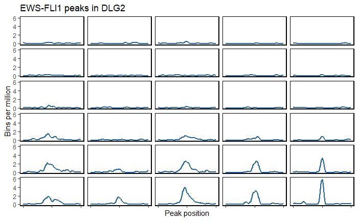

```r
##########################################################################################
#you need to run the code in the previous chunk before this because it relies on some of the objects from it
accessions = c('SRR8832669','SRR8832670','SRR8832671','SRR8832672','SRR8832673','SRR8832674')
combinedPeaks = list()
for(i in 1:length(accessions)){
  macsBw = rtracklayer::import(paste(baseRepository, '/sequencing20210114_a673ChipSeqReprocessingAynaud/',accessions[i],'.chr11.bw', sep = ''))
  macsOverlaps = findOverlaps(peakWindows, macsBw, ignore.strand = TRUE)
  macsCounts = as.data.frame(macsBw)[subjectHits(macsOverlaps),]
  macsCounts$peakId = peakWindows$peak
  macsCounts$indexLocation = rep(seq(1,2001,1), 5)
  macsCounts$dataset = accessions[i]
  ##
  combinedPeaks[[i]] = macsCounts
}
combinedPeaksCollapse = do.call('rbind', combinedPeaks)


##now try making the plot again
ggplot(combinedPeaksCollapse, aes(indexLocation, score)) +
  geom_path(color = brewer.pal(8,'RdBu')[8], size = 1) +
  scale_y_continuous(limits = c(0,6), breaks = seq(0,8,2)) +
  scale_x_continuous(limits = c(0,2005), breaks = seq(0,2000,1000)) +
  labs(x = 'Peak position', y = 'Bins per million', title = 'EWS-FLI1 peaks in DLG2') +
  facet_wrap(~dataset + peakId, nrow = 6, ncol = 5) +
  theme_classic() +
  theme(panel.border = element_rect(size = 1, fill = NA),
        strip.background = element_blank(),
        strip.text.x = element_blank(),
        axis.text.x = element_blank())
ggsave(paste(baseRepository, '/sequencing20210114_a673ChipSeqReprocessingAynaud/lineplot_dlg2ChipPeaksAll.pdf', sep = ''),
       height = 8, width = 8, useDingbats = FALSE)
```

```r
NA
NA
NA
NA
NA
```

[session information not shown]